# Pseudobulk QC

## Overview of Pseudobulk Data

First, which cell types are included in this analysis (after filtering out samples with too few cells)?

```r
options(readr.show_progress = FALSE)
sample_summary <- read_tsv("/project2/gilad/jpopp/ebQTL/data/static_qtl_calling/eb_cellid/pseudobulk_tmm/sample_summary.tsv") %>%
  mutate(individual=factor(individual), type=factor(type))
cell.types <- sample_summary  %>%
  mutate(type=as.character(type)) %>%
  filter(!dropped) %>%
  dplyr::count(type) %>%
  filter(n > 25) %>%
  pull(type)

cell.types
```

```
 [1] "Acinar-cells"                              "Adrenocortical-cells"
 [3] "Bronchiolar-and-alveolar-epithelial-cells" "CNS-glia"
 [5] "CNS-neurons"                               "Cardiomyocytes"
 [7] "Ciliated-epithelial-cells"                 "Ductal-cells"
 [9] "Epicardial-fat-cells"                      "Erythroblasts"
[11] "Goblet-cells"                              "Hepatoblasts"
[13] "Lymphoid-cells"                            "Megakaryocytes"
[15] "Mesangial-cells"                           "Mesothelial-cells"
[17] "Metanephric-cells"                         "Neuroendocrine-cells"
[19] "PNS-glia"                                  "PNS-neurons"
[21] "Parietal-and-chief-cells"                  "Retinal-cells"
[23] "Skeletal-muscle-cells"                     "Smooth-muscle-cells"
[25] "Squamous-epithelial-cells"                 "Stellate-cells"
[27] "Stromal-cells"                             "Ureteric-bud-cells"
[29] "Vascular-endothelial-cells"
```

How many samples do we have per cell type?

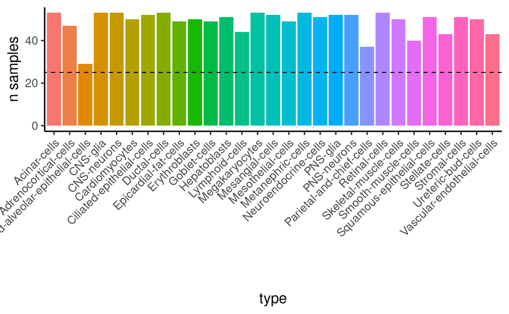

```r
sample_summary  %>%
  filter(!dropped) %>%
  dplyr::count(type) %>%
  ggplot(aes(x=type, y=n, fill=type)) +
  geom_bar(stat="identity") +
  ylab("n samples") +
  theme_classic(base_size=15) +
  theme(axis.text.x = element_text(angle = 45, hjust=1), legend.position="none") +
  geom_abline(slope=0, intercept=25, linetype="dashed")
```

How many cells do we have (median) per cell type?

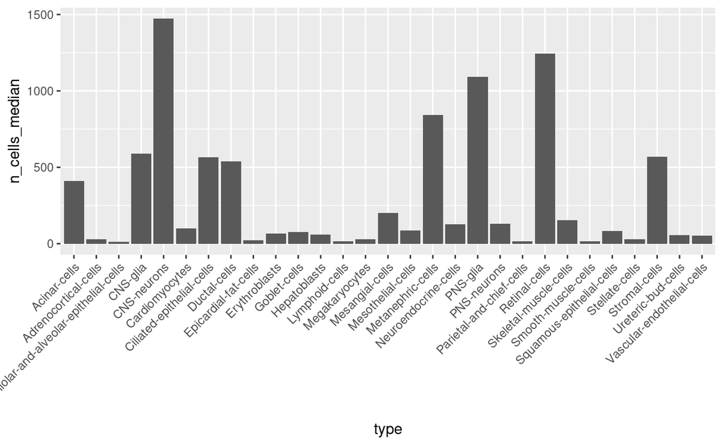

```r
sample_summary %>%
  filter(!dropped) %>%
  filter(type %in% cell.types) %>%
  group_by(type) %>%
  summarize(n_cells_median=median(n_cells_filtered)) %>%
  arrange(n_cells_median) %>%
  ggplot(aes(x=type, y=n_cells_median)) +
  geom_bar(stat="identity") +
  theme(axis.text.x = element_text(angle = 45, hjust=1))
```

And how many cell types per individual?

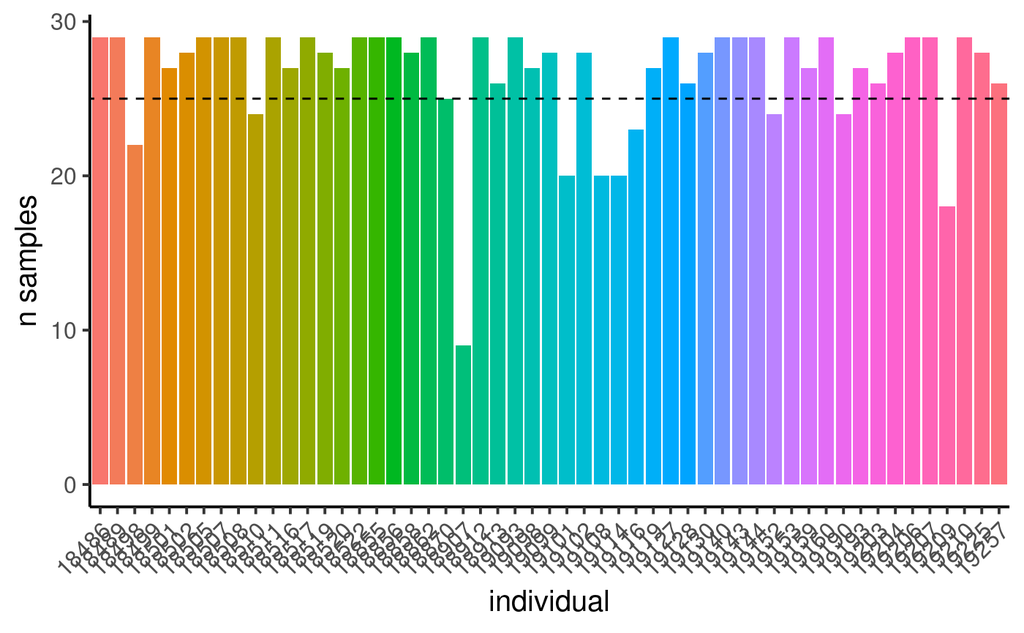

```r
sample_summary  %>%
  filter(!dropped) %>%
  dplyr::count(individual) %>%
  ggplot(aes(x=individual, y=n, fill=individual)) +
  geom_bar(stat="identity") +
  ylab("n samples") +
  theme_classic(base_size=15) +
  theme(axis.text.x = element_text(angle = 45, hjust=1), legend.position="none") +
  geom_abline(slope=0, intercept=25, linetype="dashed")
```

## Per-cell type quality control

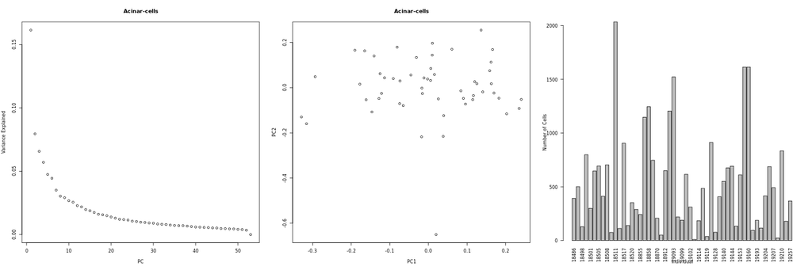

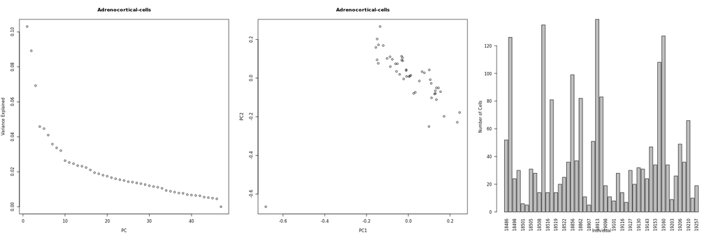

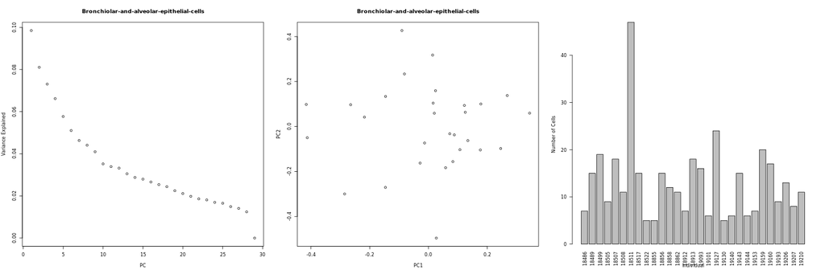

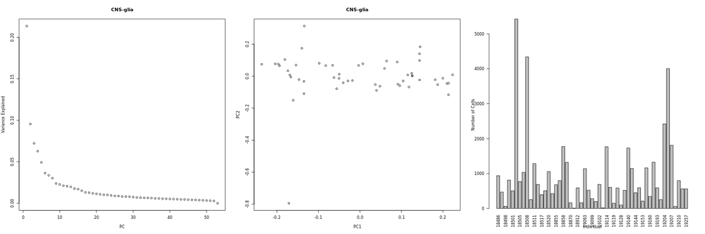

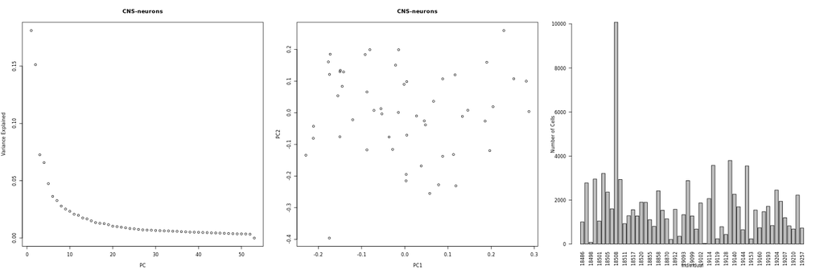

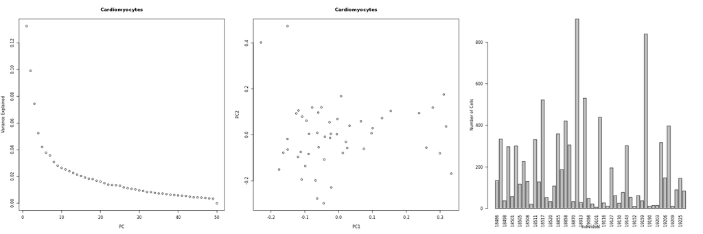

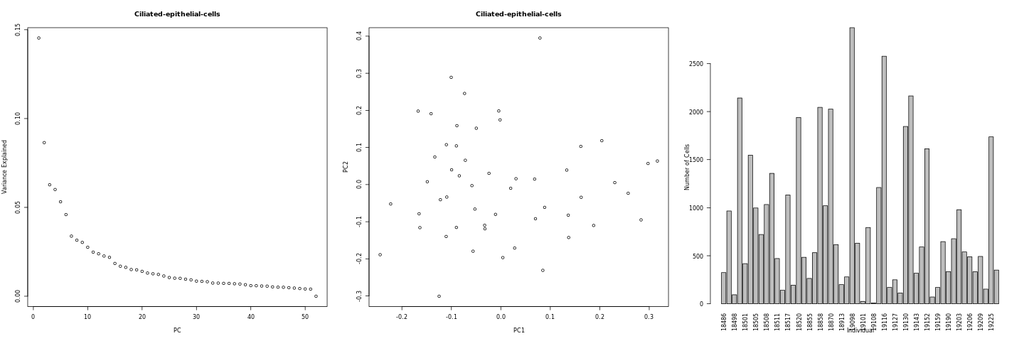

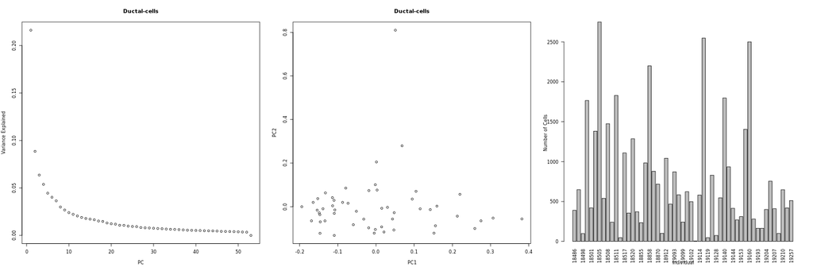

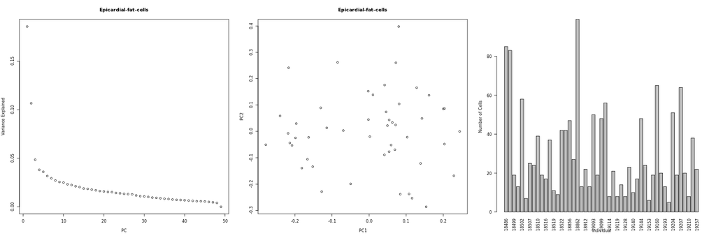

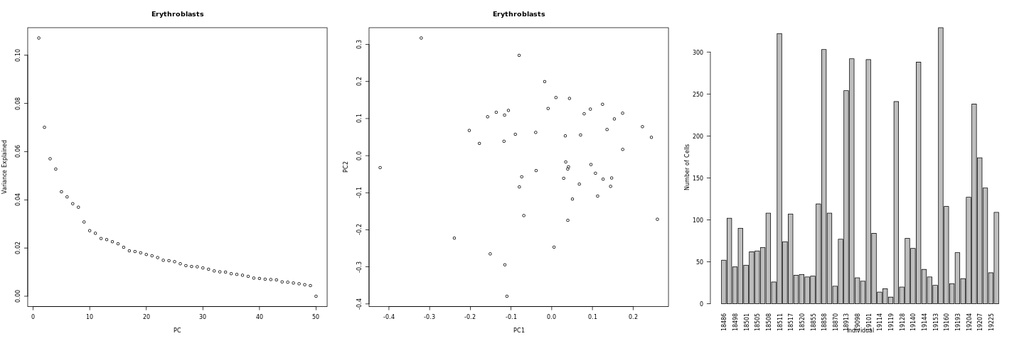

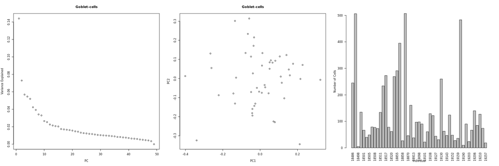

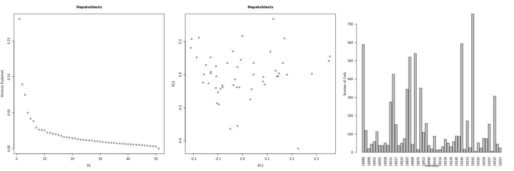

[17 more figures not shown]

```r
knitr::include_graphics(paste0("/project2/gilad/jpopp/ebQTL/figs/static_qtl_calling/eb_cellid/pseudobulk_tmm/basic/", cell.types, "/qc.png"))
```

## Assessing outliers

### Acinar cells

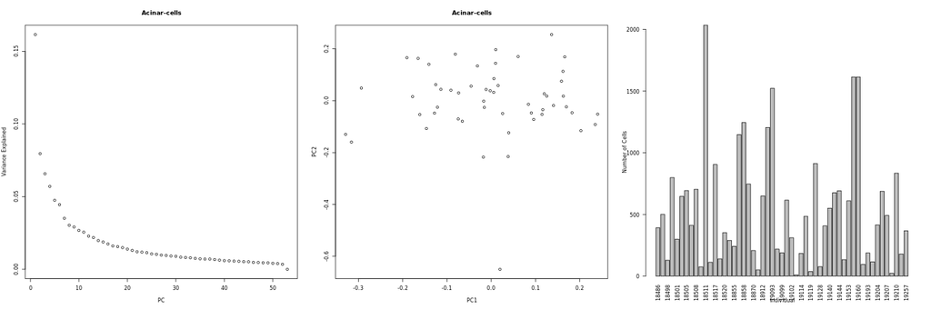

```r
knitr::include_graphics(paste0("/project2/gilad/jpopp/ebQTL/figs/static_qtl_calling/eb_cellid/pseudobulk_tmm/basic/Acinar-cells/qc.png"))
```

```r
read_tsv("/project2/gilad/jpopp/ebQTL/data/static_qtl_calling/eb_cellid/pseudobulk_tmm/basic/Acinar-cells/all_pcs.tsv") %>%
  column_to_rownames("covariate") %>% t %>% as_tibble(rownames="donor_id") %>%
  arrange(PC2)
```

| donor_id | PC1 | PC2 | PC3 | PC4 | PC5 | PC6 | PC7 | PC8 | PC9 | PC10 |
| --- | --- | --- | --- | --- | --- | --- | --- | --- | --- | --- |
| NA19108 | 0.019801898 | -0.650148880 | 0.174470993 | -0.677618470 | -0.107902641 | 0.187810125 | -0.0376451713 | 0.023617515 | -0.022312999 | 0.080400289 |
| NA18516 | -0.017816447 | -0.217586150 | -0.236123034 | 0.116195949 | -0.029442937 | -0.061205881 | 0.3240170375 | -0.206064082 | -0.002998130 | -0.210324185 |
| NA19209 | 0.038212188 | -0.215399078 | 0.059578262 | 0.183717326 | 0.814388203 | 0.153427902 | -0.3191066397 | -0.219575896 | 0.073976379 | 0.128274795 |
| NA18907 | -0.315783553 | -0.159445524 | 0.203313065 | 0.204462867 | -0.046421112 | -0.171017782 | -0.0163743503 | 0.406994718 | 0.346323651 | 0.017796398 |
| NA19153 | -0.328936588 | -0.129765432 | 0.012621396 | 0.158367972 | -0.064036286 | -0.102893302 | 0.0395448533 | -0.071031582 | -0.091272573 | 0.030961061 |
| NA19119 | 0.039481612 | -0.123598719 | -0.328668631 | 0.048408118 | -0.012936397 | -0.076111412 | -0.0726158522 | 0.483859998 | 0.327229913 | 0.241655819 |
| NA19152 | 0.202555278 | -0.115573436 | -0.029647767 | 0.116790031 | -0.113971774 | -0.313610951 | -0.2342830810 | 0.041942536 | -0.096077943 | 0.135965698 |
| NA19144 | -0.146389361 | -0.107321250 | -0.143919475 | 0.109266328 | -0.051855800 | -0.063217044 | 0.0250578942 | -0.103245409 | -0.114851982 | -0.034071155 |
| NA19116 | 0.234873617 | -0.091648266 | 0.195708268 | 0.132730908 | 0.026977815 | -0.039007940 | 0.0060653622 | 0.107784613 | -0.013869142 | -0.223827059 |
| NA18856 | -0.065262549 | -0.079184531 | -0.056142330 | 0.120199912 | -0.092141883 | 0.095256862 | 0.0881840247 | -0.117465992 | 0.103265332 | -0.004488635 |

[output cut: 43 more lines]

```r
sample_summary %>%
  filter(type=="Acinar-cells")
```

| ...1 | ind_type | individual | type | n_cells_unfiltered | dropped | total_counts | n_cells_filtered |
| --- | --- | --- | --- | --- | --- | --- | --- |
| 0 | 18511_Acinar-cells | 18511 | Acinar-cells | 2034 | FALSE | 31819778 | 2034 |
| 2 | 19159_Acinar-cells | 19159 | Acinar-cells | 1614 | FALSE | 54273453 | 1614 |
| 1 | 19160_Acinar-cells | 19160 | Acinar-cells | 1614 | FALSE | 28754221 | 1614 |
| 3 | 19093_Acinar-cells | 19093 | Acinar-cells | 1522 | FALSE | 66083478 | 1522 |
| 4 | 18858_Acinar-cells | 18858 | Acinar-cells | 1245 | FALSE | 37325138 | 1245 |
| 5 | 18913_Acinar-cells | 18913 | Acinar-cells | 1205 | FALSE | 60538016 | 1205 |
| 6 | 18856_Acinar-cells | 18856 | Acinar-cells | 1147 | FALSE | 35438127 | 1147 |
| 7 | 19127_Acinar-cells | 19127 | Acinar-cells | 913 | FALSE | 33528192 | 913 |
| 8 | 18517_Acinar-cells | 18517 | Acinar-cells | 905 | FALSE | 31159574 | 905 |
| 9 | 19210_Acinar-cells | 19210 | Acinar-cells | 835 | FALSE | 26162547 | 835 |

[output cut: 43 more lines]

NA19108 has the fewest cells, and appears to be an outlier, so we’ll remove that sample from the analysis

### Adrenocortical cells

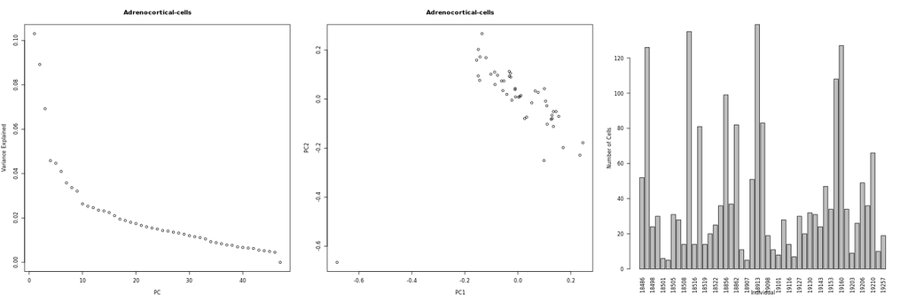

```r
knitr::include_graphics(paste0("/project2/gilad/jpopp/ebQTL/figs/static_qtl_calling/eb_cellid/pseudobulk_tmm/basic/Adrenocortical-cells/qc.png"))
```

```r
read_tsv("/project2/gilad/jpopp/ebQTL/data/static_qtl_calling/eb_cellid/pseudobulk_tmm/basic/Adrenocortical-cells/all_pcs.tsv") %>%
  column_to_rownames("covariate") %>% t %>% as_tibble(rownames="donor_id") %>%
  arrange(PC2)
```

| donor_id | PC1 | PC2 | PC3 | PC4 | PC5 | PC6 | PC7 | PC8 | PC9 | PC10 |
| --- | --- | --- | --- | --- | --- | --- | --- | --- | --- | --- |
| NA18907 | -0.682230006 | -0.666035213 | 0.135706231 | -0.070975203 | 0.160222053 | 0.057945771 | 0.002514815 | 0.056620214 | 0.016573715 | -0.016285371 |
| NA19119 | 0.098969414 | -0.250849095 | 0.008138125 | -0.257527786 | -0.700801533 | -0.275626984 | 0.486905434 | -0.084231296 | -0.006288608 | -0.035831736 |
| NA18520 | 0.234461524 | -0.228710135 | 0.079084452 | 0.354906326 | -0.046881432 | -0.093631934 | -0.174296712 | 0.367809971 | -0.112758283 | -0.031397828 |
| NA19116 | 0.171434226 | -0.197727705 | 0.174274081 | 0.032432821 | -0.081593045 | -0.203540307 | -0.519051981 | -0.617686259 | 0.358275410 | 0.078296656 |
| NA18522 | 0.245940920 | -0.177927668 | 0.096922528 | 0.095346615 | 0.005589381 | 0.013214891 | -0.052161958 | 0.176439699 | -0.122307574 | -0.030453867 |
| NA19140 | 0.134492924 | -0.111485299 | 0.065299833 | 0.273483928 | 0.072657112 | -0.003006964 | 0.094639405 | 0.084879793 | -0.077533435 | -0.032849964 |
| NA19206 | 0.110997034 | -0.102362009 | -0.212991596 | 0.050065347 | -0.010209679 | -0.125009125 | -0.109275449 | 0.068166969 | -0.077527125 | -0.078166354 |
| NA19098 | 0.125789195 | -0.082054388 | -0.012710324 | -0.007453240 | 0.049210625 | 0.141425750 | 0.094592687 | -0.085210261 | 0.030243340 | 0.013515968 |
| NA19225 | 0.129687262 | -0.079688053 | -0.058922246 | 0.009187949 | 0.126033447 | 0.383703627 | 0.250614556 | -0.065909292 | 0.278358468 | 0.517627919 |
| NA18499 | 0.026087958 | -0.079202794 | -0.170795968 | 0.225995460 | 0.017133902 | -0.067823701 | -0.017682571 | -0.032333541 | -0.088831618 | 0.098646575 |

[output cut: 37 more lines]

```r
sample_summary %>%
  filter(type=="Adrenocortical-cells")
```

[output not shown]

NA18907 is on the lower end of the number of cells, and appears to be a strong outlier, so we’ll remove that sample from the analysis as well

### CNS glia

```r
knitr::include_graphics(paste0("/project2/gilad/jpopp/ebQTL/figs/static_qtl_calling/eb_cellid/pseudobulk_tmm/basic/CNS-glia/qc.png"))
```

[output not shown]

```r
read_tsv("/project2/gilad/jpopp/ebQTL/data/static_qtl_calling/eb_cellid/pseudobulk_tmm/basic/CNS-glia/all_pcs.tsv") %>%
  column_to_rownames("covariate") %>% t %>% as_tibble(rownames="donor_id") %>%
  arrange(PC2)
```

[output not shown]

```r
sample_summary %>%
  filter(type=="CNS-glia")
```

[output not shown]

NA18907 has the fewest cells, and appears to be an outlier, so we’ll remove that sample from the analysis

## CNS-neurons

```r
knitr::include_graphics(paste0("/project2/gilad/jpopp/ebQTL/figs/static_qtl_calling/eb_cellid/pseudobulk_tmm/basic/CNS-neurons/qc.png"))
```

[output not shown]

```r
read_tsv("/project2/gilad/jpopp/ebQTL/data/static_qtl_calling/eb_cellid/pseudobulk_tmm/basic/CNS-neurons/all_pcs.tsv") %>%
  column_to_rownames("covariate") %>% t %>% as_tibble(rownames="donor_id") %>%
  arrange(PC2)
```

[output not shown]

This is yet another cell type where 18907 is looking like an outlier, and it was already in the fewest cell types, so we are going to remove all samples from this donor

### Cardiomyocytes

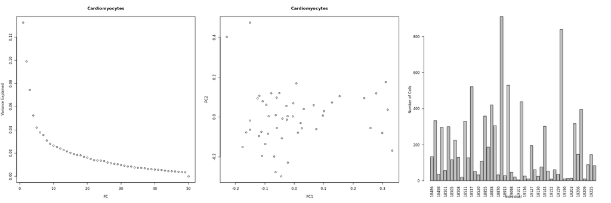

```r
knitr::include_graphics(paste0("/project2/gilad/jpopp/ebQTL/figs/static_qtl_calling/eb_cellid/pseudobulk_tmm/basic/Cardiomyocytes/qc.png"))
```

```r
read_tsv("/project2/gilad/jpopp/ebQTL/data/static_qtl_calling/eb_cellid/pseudobulk_tmm/basic/Cardiomyocytes/all_pcs.tsv") %>%
  column_to_rownames("covariate") %>% t %>% as_tibble(rownames="donor_id") %>%
  arrange(desc(PC2))
```

| donor_id | PC1 | PC2 | PC3 | PC4 | PC5 | PC6 | PC7 | PC8 | PC9 | PC10 |
| --- | --- | --- | --- | --- | --- | --- | --- | --- | --- | --- |
| NA19193 | -0.150787470 | 0.473154526 | 0.180956909 | 0.048837297 | 0.234428129 | 0.126509496 | -0.260531643 | 0.5021649127 | 0.0236223833 | 0.255883437 |
| NA19152 | -0.229347863 | 0.401474861 | 0.122794424 | 0.243386436 | 0.084829976 | 0.070735133 | 0.026803766 | -0.6959562641 | 0.3139442245 | -0.047162316 |
| NA18510 | 0.310710128 | 0.175552715 | 0.149526120 | 0.003605622 | 0.041487447 | -0.101036704 | 0.147654975 | -0.0499821024 | -0.0433921257 | -0.004256286 |
| NA19257 | 0.007185572 | 0.168585715 | -0.066443537 | -0.070089784 | -0.129288917 | -0.069505108 | 0.166176328 | 0.0233607722 | -0.0120543730 | -0.006033918 |
| NA19204 | -0.050758011 | 0.119676896 | -0.078753926 | 0.017121060 | 0.048804138 | -0.081764505 | 0.169611870 | 0.0526583618 | -0.0812694696 | -0.159586569 |
| NA18507 | -0.078117036 | 0.119072131 | 0.095392445 | -0.050640473 | -0.108261308 | 0.032568212 | -0.114249626 | -0.0820549178 | -0.0699861619 | 0.186167128 |
| NA19190 | 0.278367256 | 0.118830423 | -0.278625300 | -0.025495242 | -0.074790648 | -0.335132484 | -0.553424960 | -0.0356359976 | 0.2757445690 | -0.186018362 |
| NA19102 | -0.118604578 | 0.106285384 | -0.034343234 | -0.042208210 | 0.022282825 | -0.024131139 | 0.002318622 | -0.0187986975 | -0.1060369736 | -0.047084946 |
| NA19128 | 0.154232051 | 0.104479845 | -0.295681547 | 0.008477476 | -0.134782792 | -0.173502434 | -0.044148645 | 0.0723514045 | -0.0036488313 | -0.076279846 |
| NA19207 | -0.060052722 | 0.097276485 | -0.039461937 | -0.115471142 | -0.055312043 | -0.036569408 | 0.099313946 | -0.0427647063 | -0.1189147809 | -0.007946225 |

[output cut: 40 more lines]

```r
sample_summary %>%
  filter(type=="Cardiomyocytes")
```

| ...1 | ind_type | individual | type | n_cells_unfiltered | dropped | total_counts | n_cells_filtered |
| --- | --- | --- | --- | --- | --- | --- | --- |
| 265 | 18912_Cardiomyocytes | 18912 | Cardiomyocytes | 911 | FALSE | 39746147 | 911 |
| 266 | 19160_Cardiomyocytes | 19160 | Cardiomyocytes | 839 | FALSE | 17789280 | 839 |
| 267 | 19093_Cardiomyocytes | 19093 | Cardiomyocytes | 530 | FALSE | 25440217 | 530 |
| 268 | 18517_Cardiomyocytes | 18517 | Cardiomyocytes | 522 | FALSE | 25577412 | 522 |
| 269 | 19102_Cardiomyocytes | 19102 | Cardiomyocytes | 438 | FALSE | 23724266 | 438 |
| 270 | 18858_Cardiomyocytes | 18858 | Cardiomyocytes | 421 | FALSE | 22886711 | 421 |
| 271 | 19207_Cardiomyocytes | 19207 | Cardiomyocytes | 397 | FALSE | 20868438 | 397 |
| 272 | 18855_Cardiomyocytes | 18855 | Cardiomyocytes | 359 | FALSE | 15118803 | 359 |
| 273 | 18489_Cardiomyocytes | 18489 | Cardiomyocytes | 334 | FALSE | 13151372 | 334 |
| 274 | 18511_Cardiomyocytes | 18511 | Cardiomyocytes | 331 | FALSE | 7505196 | 331 |

[output cut: 43 more lines]

NA19152 and NA19193 are both on the low end in terms of number of cells, and appear to be outliers, so we’ll remove those

### Ductal cells

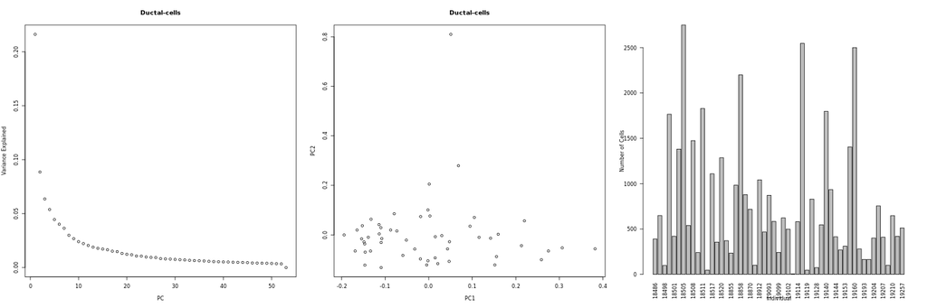

```r
knitr::include_graphics(paste0("/project2/gilad/jpopp/ebQTL/figs/static_qtl_calling/eb_cellid/pseudobulk_tmm/basic/Ductal-cells/qc.png"))
```

```r
read_tsv("/project2/gilad/jpopp/ebQTL/data/static_qtl_calling/eb_cellid/pseudobulk_tmm/basic/Ductal-cells/all_pcs.tsv") %>%
  column_to_rownames("covariate") %>% t %>% as_tibble(rownames="donor_id") %>%
  arrange(desc(PC2))
```

[output not shown]

```r
sample_summary %>%
  filter(type=="Ductal-cells")
```

| ...1 | ind_type | individual | type | n_cells_unfiltered | dropped | total_counts | n_cells_filtered |
| --- | --- | --- | --- | --- | --- | --- | --- |
| 371 | 18505_Ductal-cells | 18505 | Ductal-cells | 2749 | FALSE | 55758813 | 2749 |
| 372 | 19116_Ductal-cells | 19116 | Ductal-cells | 2546 | FALSE | 39600734 | 2546 |
| 373 | 19160_Ductal-cells | 19160 | Ductal-cells | 2500 | FALSE | 32649957 | 2500 |
| 374 | 18858_Ductal-cells | 18858 | Ductal-cells | 2199 | FALSE | 41547195 | 2199 |
| 375 | 18511_Ductal-cells | 18511 | Ductal-cells | 1829 | FALSE | 21018447 | 1829 |
| 376 | 19140_Ductal-cells | 19140 | Ductal-cells | 1797 | FALSE | 27099338 | 1797 |
| 377 | 18499_Ductal-cells | 18499 | Ductal-cells | 1766 | FALSE | 30559041 | 1766 |
| 378 | 18508_Ductal-cells | 18508 | Ductal-cells | 1475 | FALSE | 27444562 | 1475 |
| 379 | 19159_Ductal-cells | 19159 | Ductal-cells | 1405 | FALSE | 26702191 | 1405 |
| 380 | 18502_Ductal-cells | 18502 | Ductal-cells | 1381 | FALSE | 28155036 | 1381 |

[output cut: 43 more lines]

NA19108 has far fewer cells than other samples and does appear to be an outlier, will remove

### Hepatoblasts

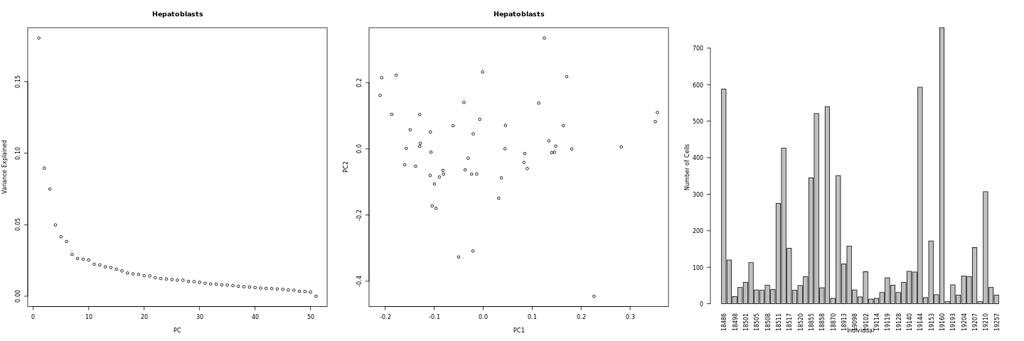

```r
knitr::include_graphics(paste0("/project2/gilad/jpopp/ebQTL/figs/static_qtl_calling/eb_cellid/pseudobulk_tmm/basic/Hepatoblasts/qc.png"))
```

```r
read_tsv("/project2/gilad/jpopp/ebQTL/data/static_qtl_calling/eb_cellid/pseudobulk_tmm/basic/Hepatoblasts/all_pcs.tsv") %>%
  column_to_rownames("covariate") %>% t %>% as_tibble(rownames="donor_id") %>%
  arrange(PC2)
```

| donor_id | PC1 | PC2 | PC3 | PC4 | PC5 | PC6 | PC7 | PC8 | PC9 | PC10 |
| --- | --- | --- | --- | --- | --- | --- | --- | --- | --- | --- |
| NA19190 | 0.226349743 | -0.4452589889 | -0.137717507 | 0.3269141915 | 0.2747126419 | -0.6946647872 | -0.133360539 | -0.078221686 | -0.024141439 | 0.030774402 |
| NA19257 | -0.050002128 | -0.3268521820 | 0.042308930 | -0.0074287841 | 0.0398832420 | 0.2220318951 | -0.007355037 | 0.262149457 | -0.231494189 | -0.011787432 |
| NA19119 | -0.020956910 | -0.3086257922 | -0.049380005 | -0.2524704286 | -0.0351015651 | 0.1371705889 | -0.031615847 | -0.010762436 | 0.055819741 | -0.006129495 |
| NA18913 | -0.096405569 | -0.1795980962 | 0.112697747 | -0.0372028362 | 0.0189763332 | 0.0087622003 | 0.063047651 | 0.024034425 | 0.040851977 | -0.014659267 |
| NA18516 | -0.104170707 | -0.1722871138 | -0.156816065 | -0.1388298821 | -0.0379565879 | 0.0793693468 | -0.183635948 | 0.004650352 | 0.063604186 | -0.076193038 |
| NA19128 | 0.031725530 | -0.1493277264 | -0.131141940 | -0.2056355042 | -0.0504325096 | 0.0364699129 | -0.086067560 | -0.054457443 | 0.095028356 | -0.125137222 |
| NA19207 | -0.099522462 | -0.1065942258 | 0.032904183 | -0.0810244996 | 0.0005828726 | 0.0051733570 | -0.036227033 | 0.052448446 | 0.040270922 | 0.058502797 |
| NA19130 | 0.037096743 | -0.0877031043 | -0.219231219 | -0.1102559848 | -0.0981464320 | 0.0431568144 | -0.042346415 | -0.053607124 | 0.023589843 | -0.020299340 |
| NA19204 | -0.089418046 | -0.0852950872 | -0.038527064 | -0.0513029524 | 0.0394476357 | -0.0133748976 | -0.012858343 | 0.252420412 | -0.083628193 | 0.011398412 |
| NA19102 | -0.108217757 | -0.0801127728 | 0.115965207 | -0.0250908520 | -0.0073521325 | -0.0002243849 | -0.055113713 | 0.044775079 | -0.021166716 | -0.006308211 |

[output cut: 41 more lines]

```r
sample_summary %>%
  filter(type=="Hepatoblasts")
```

| ...1 | ind_type | individual | type | n_cells_unfiltered | dropped | total_counts | n_cells_filtered |
| --- | --- | --- | --- | --- | --- | --- | --- |
| 636 | 19160_Hepatoblasts | 19160 | Hepatoblasts | 756 | FALSE | 23419853 | 756 |
| 637 | 19144_Hepatoblasts | 19144 | Hepatoblasts | 593 | FALSE | 40993851 | 593 |
| 638 | 18486_Hepatoblasts | 18486 | Hepatoblasts | 588 | FALSE | 28988658 | 588 |
| 639 | 18862_Hepatoblasts | 18862 | Hepatoblasts | 540 | FALSE | 30537388 | 540 |
| 640 | 18856_Hepatoblasts | 18856 | Hepatoblasts | 521 | FALSE | 26440405 | 521 |
| 641 | 18516_Hepatoblasts | 18516 | Hepatoblasts | 426 | FALSE | 21286766 | 426 |
| 642 | 18912_Hepatoblasts | 18912 | Hepatoblasts | 351 | FALSE | 19583649 | 351 |
| 643 | 18855_Hepatoblasts | 18855 | Hepatoblasts | 345 | FALSE | 17612781 | 345 |
| 644 | 19210_Hepatoblasts | 19210 | Hepatoblasts | 307 | FALSE | 16248356 | 307 |
| 645 | 18511_Hepatoblasts | 18511 | Hepatoblasts | 275 | FALSE | 9518417 | 275 |

[output cut: 43 more lines]

We’ll remove NA19190 since it’s got the least cells and looks like an outlier

### Metanephric cells

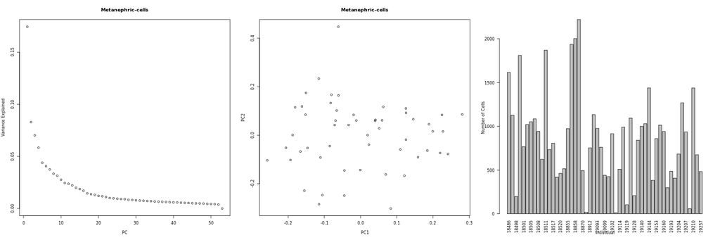

```r
knitr::include_graphics(paste0("/project2/gilad/jpopp/ebQTL/figs/static_qtl_calling/eb_cellid/pseudobulk_tmm/basic/Metanephric-cells/qc.png"))
```

```r
read_tsv("/project2/gilad/jpopp/ebQTL/data/static_qtl_calling/eb_cellid/pseudobulk_tmm/basic/Metanephric-cells/all_pcs.tsv") %>%
  column_to_rownames("covariate") %>% t %>% as_tibble(rownames="donor_id") %>%
  arrange(PC2)
```

[output not shown]

```r
sample_summary %>%
  filter(type=="Metanephric-cells")
```

| ...1 | ind_type | individual | type | n_cells_unfiltered | dropped | total_counts | n_cells_filtered |
| --- | --- | --- | --- | --- | --- | --- | --- |
| 1007 | 18862_Metanephric-cells | 18862 | Metanephric-cells | 2221 | FALSE | 72130546 | 2221 |
| 1008 | 18858_Metanephric-cells | 18858 | Metanephric-cells | 2003 | FALSE | 69798154 | 2003 |
| 1009 | 18856_Metanephric-cells | 18856 | Metanephric-cells | 1936 | FALSE | 60475964 | 1936 |
| 1010 | 18511_Metanephric-cells | 18511 | Metanephric-cells | 1871 | FALSE | 26982452 | 1871 |
| 1011 | 18499_Metanephric-cells | 18499 | Metanephric-cells | 1811 | FALSE | 50665647 | 1811 |
| 1012 | 18486_Metanephric-cells | 18486 | Metanephric-cells | 1616 | FALSE | 39479623 | 1616 |
| 1013 | 19144_Metanephric-cells | 19144 | Metanephric-cells | 1439 | FALSE | 50556987 | 1439 |
| 1014 | 19210_Metanephric-cells | 19210 | Metanephric-cells | 1438 | FALSE | 46843534 | 1438 |
| 1015 | 19206_Metanephric-cells | 19206 | Metanephric-cells | 1268 | FALSE | 29104006 | 1268 |
| 1016 | 18913_Metanephric-cells | 18913 | Metanephric-cells | 1134 | FALSE | 54903615 | 1134 |

[output cut: 43 more lines]

Once again, donor with the fewest cells looks like an outlier, so we’ll remove NA19108

### Parietal and chief cells

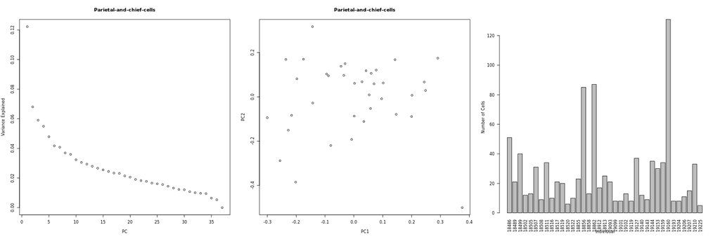

```r
knitr::include_graphics(paste0("/project2/gilad/jpopp/ebQTL/figs/static_qtl_calling/eb_cellid/pseudobulk_tmm/basic/Parietal-and-chief-cells/qc.png"))
```

```r
read_tsv("/project2/gilad/jpopp/ebQTL/data/static_qtl_calling/eb_cellid/pseudobulk_tmm/basic/Parietal-and-chief-cells/all_pcs.tsv") %>%
  column_to_rownames("covariate") %>% t %>% as_tibble(rownames="donor_id") %>%
  arrange(desc(PC1))
```

[output not shown]

```r
sample_summary %>%
  filter(type=="Parietal-and-chief-cells")
```

| ...1 | ind_type | individual | type | n_cells_unfiltered | dropped | total_counts | n_cells_filtered |
| --- | --- | --- | --- | --- | --- | --- | --- |
| 1219 | 19160_Parietal-and-chief-cells | 19160 | Parietal-and-chief-cells | 131 | FALSE | 2146106 | 131 |
| 1220 | 18862_Parietal-and-chief-cells | 18862 | Parietal-and-chief-cells | 87 | FALSE | 2223608 | 87 |
| 1221 | 18856_Parietal-and-chief-cells | 18856 | Parietal-and-chief-cells | 85 | FALSE | 2658680 | 85 |
| 1222 | 18486_Parietal-and-chief-cells | 18486 | Parietal-and-chief-cells | 51 | FALSE | 1158650 | 51 |
| 1223 | 18499_Parietal-and-chief-cells | 18499 | Parietal-and-chief-cells | 40 | FALSE | 1103864 | 40 |
| 1224 | 19127_Parietal-and-chief-cells | 19127 | Parietal-and-chief-cells | 37 | FALSE | 1427808 | 37 |
| 1225 | 19144_Parietal-and-chief-cells | 19144 | Parietal-and-chief-cells | 35 | FALSE | 852026 | 35 |
| 1227 | 18511_Parietal-and-chief-cells | 18511 | Parietal-and-chief-cells | 34 | FALSE | 543468 | 34 |
| 1226 | 19159_Parietal-and-chief-cells | 19159 | Parietal-and-chief-cells | 34 | FALSE | 1084611 | 34 |
| 1228 | 19210_Parietal-and-chief-cells | 19210 | Parietal-and-chief-cells | 33 | FALSE | 772785 | 33 |

[output cut: 43 more lines]

NA19225 removed, fewest cells and appears an outlier

### Retinal cells

```r
knitr::include_graphics(paste0("/project2/gilad/jpopp/ebQTL/figs/static_qtl_calling/eb_cellid/pseudobulk_tmm/basic/Retinal-cells/qc.png"))
```

[output not shown]

```r
read_tsv("/project2/gilad/jpopp/ebQTL/data/static_qtl_calling/eb_cellid/pseudobulk_tmm/basic/Retinal-cells/all_pcs.tsv") %>%
  column_to_rownames("covariate") %>% t %>% as_tibble(rownames="donor_id") %>%
  arrange(desc(PC2))
```

[output not shown]

```r
sample_summary %>%
  filter(type=="Retinal-cells")
```

[output not shown]

Just NA18907, which was going to be removed anyway

### Skeletal muscle cells

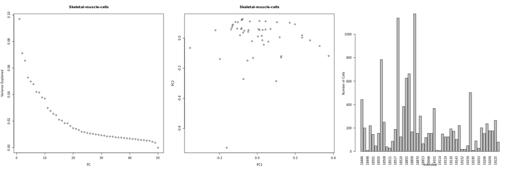

```r
knitr::include_graphics(paste0("/project2/gilad/jpopp/ebQTL/figs/static_qtl_calling/eb_cellid/pseudobulk_tmm/basic/Skeletal-muscle-cells/qc.png"))
```

```r
read_tsv("/project2/gilad/jpopp/ebQTL/data/static_qtl_calling/eb_cellid/pseudobulk_tmm/basic/Skeletal-muscle-cells/all_pcs.tsv") %>%
  column_to_rownames("covariate") %>% t %>% as_tibble(rownames="donor_id") %>%
  arrange(PC2)
```

| donor_id | PC1 | PC2 | PC3 | PC4 | PC5 | PC6 | PC7 | PC8 | PC9 | PC10 |
| --- | --- | --- | --- | --- | --- | --- | --- | --- | --- | --- |
| NA19114 | -0.161654236 | -0.727928702 | 0.258807801 | 0.0029634414 | -0.379263753 | -0.062052529 | -0.187155546 | -0.3805468556 | -0.097407410 | 0.036530065 |
| NA18520 | 0.099410449 | -0.285761381 | -0.064770637 | -0.0024116209 | 0.092295580 | -0.136069499 | 0.183468119 | 0.2381099446 | 0.125557759 | 0.124951266 |
| NA19152 | -0.073230574 | -0.272177671 | 0.203526662 | 0.0662169701 | 0.225246481 | 0.291846433 | 0.141123962 | 0.5199364581 | -0.066289265 | -0.022653302 |
| NA19130 | -0.052018171 | -0.149284149 | 0.060538214 | 0.0365522973 | 0.148980609 | -0.003682242 | 0.109676693 | 0.1210135754 | 0.049652717 | -0.113885989 |
| NA19193 | -0.197624895 | -0.138750712 | 0.021631142 | 0.0717315957 | 0.224084090 | 0.056205372 | 0.253650221 | 0.0304186763 | 0.119515469 | -0.186538559 |
| NA19153 | -0.022758460 | -0.131614144 | -0.369551340 | 0.2223853685 | 0.009679450 | 0.218453264 | 0.051379012 | -0.2151642885 | 0.481622126 | 0.105220803 |
| NA18517 | 0.124493081 | -0.128693165 | -0.114508843 | -0.0773721826 | 0.173119276 | -0.163501965 | 0.168909949 | 0.0107743569 | -0.046623206 | 0.074417364 |
| NA18912 | 0.126355618 | -0.119949172 | -0.172021361 | -0.0013892309 | 0.073602719 | -0.214010475 | 0.135389717 | -0.0513645327 | -0.045269022 | -0.018816113 |
| NA18511 | 0.375899356 | -0.117945347 | -0.199805555 | 0.1039677775 | 0.070812734 | 0.366074756 | -0.307046242 | -0.0280725118 | -0.301175107 | -0.494795420 |
| NA18498 | -0.354674308 | -0.064947398 | -0.407084966 | -0.6386695740 | 0.003485085 | -0.090857560 | -0.412391737 | 0.2398434379 | 0.064618202 | -0.107818089 |

[output cut: 40 more lines]

```r
sample_summary %>%
  filter(type=="Skeletal-muscle-cells")
```

| ...1 | ind_type | individual | type | n_cells_unfiltered | dropped | total_counts | n_cells_filtered |
| --- | --- | --- | --- | --- | --- | --- | --- |
| 1378 | 18862_Skeletal-muscle-cells | 18862 | Skeletal-muscle-cells | 1174 | FALSE | 38802517 | 1174 |
| 1379 | 18519_Skeletal-muscle-cells | 18519 | Skeletal-muscle-cells | 1138 | FALSE | 36075462 | 1138 |
| 1380 | 18507_Skeletal-muscle-cells | 18507 | Skeletal-muscle-cells | 784 | FALSE | 23859013 | 784 |
| 1381 | 18856_Skeletal-muscle-cells | 18856 | Skeletal-muscle-cells | 663 | FALSE | 18720075 | 663 |
| 1382 | 18855_Skeletal-muscle-cells | 18855 | Skeletal-muscle-cells | 625 | FALSE | 18305543 | 625 |
| 1383 | 19160_Skeletal-muscle-cells | 19160 | Skeletal-muscle-cells | 502 | FALSE | 7824986 | 502 |
| 1384 | 18486_Skeletal-muscle-cells | 18486 | Skeletal-muscle-cells | 443 | FALSE | 10212151 | 443 |
| 1385 | 18522_Skeletal-muscle-cells | 18522 | Skeletal-muscle-cells | 384 | FALSE | 12039584 | 384 |
| 1386 | 19102_Skeletal-muscle-cells | 19102 | Skeletal-muscle-cells | 366 | FALSE | 14621612 | 366 |
| 1387 | 18912_Skeletal-muscle-cells | 18912 | Skeletal-muscle-cells | 302 | FALSE | 8262704 | 302 |

[output cut: 43 more lines]

Will remove NA19114